# Rmarkdown Workshop

A basic Introduction

Fabio Votta

# This is the beginning

## Why Rmarkdown?

- Code, results, and text in the same document
- Your results and plots are automatically generated from your data, so your documents can be easily updated if your data changes
- Outputs can be directly deployed online
  - Integrates nicely with GitHub Pages and other hosting services
- Reproducible Workflow - from raw data over analysis to presentation

[figure not shown]

## YAML Header

A YAML header is a set of key-value pairs at the start of your file. The YAML header includes meta-information about your Rmarkdown document. For example whether the output should be an HTML or a PDF document. Begin and end the header with a line of three dashes (- - -)

```r
---
title: "Rmarkdown Workshop"
subtitle: "A basic Introduction"
author: "Fabio Votta"
output: html_document
---
```

### Possible outputs:

- output: html_document
- output: pdf_document
- output: word_document
- output: beamer_presentation
- output: ioslides_presentation

## Rmarkdown Syntax

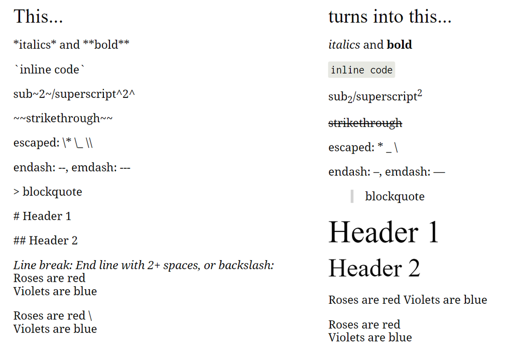

**CODING EXAMPLE**

*italics* and **bold**

`inline code`

sub<sub>2</sub>/superscript<sup>2</sup>

strikethrough

escaped: * _ \

endash: –, emdash: —

> blockquote

# Header 1

## Header 2

Line break: End line with 2+ spaces, or backslash: Roses are red Violets are blue

Roses are red  
Violets are blue

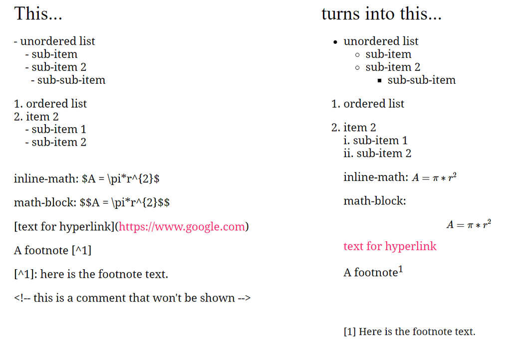

**CODING EXAMPLE**

1. ordered list
2. item 2
   - sub-item 1
   - sub-item 2

inline-math: $A = \pi*r^{2}$

math-block:
$$A = \pi*r^{2}$$

[text for hyperlink](https://www.google.com)

A footnote [^1]

## Introducing a Code Chunk

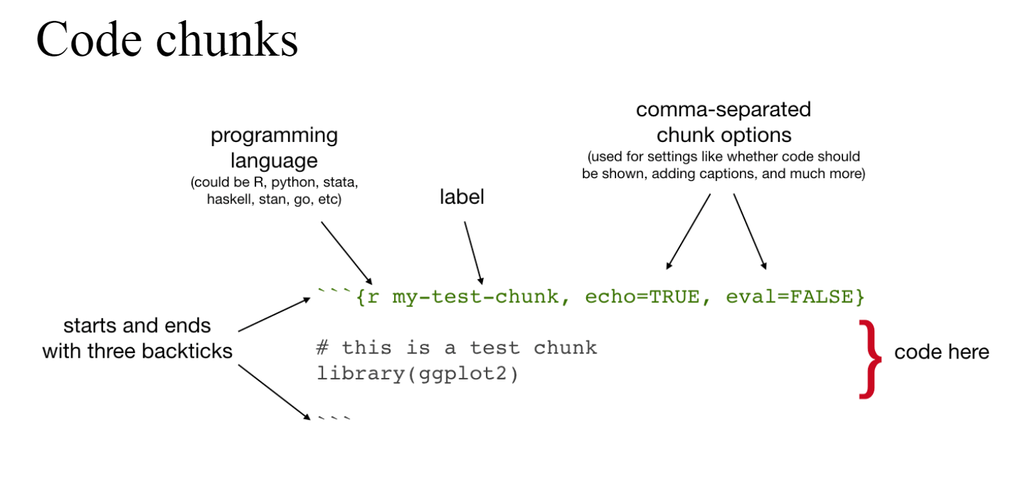

### A Special Kind of Chunk

In a setup chunk, one usually sets global options for the entire document.

Normally, an R Markdown document starts with this chunk.

`knitr::opts_chunk$set` sets default options for all chunks.

```r
library(tidyverse)
## Sets Global Options
knitr::opts_chunk$set(echo = T, warning = F, message = F)
```

| option | default | effect |
| --- | --- | --- |
| eval | TRUE | Whether to evaluate the code and include its results |
| echo | TRUE | Whether to display code along with its results |
| warning | TRUE | Whether to display warnings |
| error | FALSE | Whether to display errors |
| message | TRUE | Whether to display messages |
| tidy | FALSE | Whether to reformat code in a tidy way when displaying it |
| results | “markup” | “markup”, “asis”, “hold”, or “hide” |
| cache | FALSE | Whether to cache results for future renders |
| comment | “##” | Comment character to preface results with |
| fig.width | 7 | Width in inches for plots created in chunk |
| fig.height | 7 | Height in inches for plots created in chunk |

## Including Tables

```r
cars %>%
  head() %>%
  knitr::kable()
```

| speed | dist |
| --- | --- |
| 4 | 2 |
| 4 | 10 |
| 7 | 4 |
| 7 | 22 |
| 8 | 16 |
| 9 | 10 |

The `kable` function within `knitr` produces neat tables out of dataframes. A number of other packages are available for making pretty tables, see rmarkdown.rstudio.com.

```r
result <- 4 + 4
```

# Links for futher learning:

- [RMarkdown for writing reproducible scientific papers](https://libscie.github.io/rmarkdown-workshop/handout.html)
- [Intro to Rmarkdown by Rstudio](https://rmarkdown.rstudio.com/lesson-1.html)
- [Rmarkdown Cheatsheet](https://rstudio.com/wp-content/uploads/2015/02/rmarkdown-cheatsheet.pdf)
- [Advanced Rmarkdown Workshop](https://arm.rbind.io/)
- [R Markdown: The Definitive Guide (Yihui Xie, J. J. Allaire, Garrett Grolemund)](https://bookdown.org/yihui/rmarkdown/)
- [Writing Reproducible Research Papers with R Markdown](https://resulumit.com/teaching/rmd_workshop.html)
- [Starting R markdown (YouTube Intro series with the magnificent Danielle Navarro)](https://www.youtube.com/watch?v=tuFn-sFSVgk)
[^1]: here is the footnote text.